# Anomaly Detection in Network Traffic with K-means clustering

#### Question 1.7

The code below can be used to test your algorithm with three different datasets: `Iris`, `Moon` and `Blob`. Run your algorithm to cluster datapoints in these datasets, plot the results and discuss about them. Do you think that our algorithm works well? Why?

```python
import copy

def is_label_right(labels, y_iris):
    labels1 = [(labels[i]-1)%3 for i in range(len(labels))]
    labels2 = [(labels[i]-2)%3 for i in range(len(labels))]
    labels3 = copy.copy(labels)
    labels4 = copy.copy(labels)
    labels5 = copy.copy(labels)

    for i in range(len(labels3)):
        if (labels3[i] == 1 or labels3[i] == 2):
            labels3[i] = (labels3[i])%2 + 1

    for i in range(len(labels4)):
        if (labels4[i] == 0 or labels4[i] == 2):
            labels4[i] = (labels4[i]+2)%4


    for i in range(len(labels5)):
        if (labels5[i] == 0 or labels5[i] == 1):
            labels5[i] = (labels5[i]+1)%2


#we take the maximum of the 6 possibilities because the centroid 0 is chosen randomly at the begining and doesn't correspond
#for sure at the label 0 and it is the same for labels 1 and 2 so we did permutations
    right_labels = max(sum(labels == y_iris), sum(labels1 == y_iris), sum(labels2 == y_iris), sum(labels3 == y_iris), sum(labels4 == y_iris), \
                       sum(labels5 == y_iris) )
    return str(right_labels)
```

```
134 out of 150 were well predicted by our kmeans algorithm
```

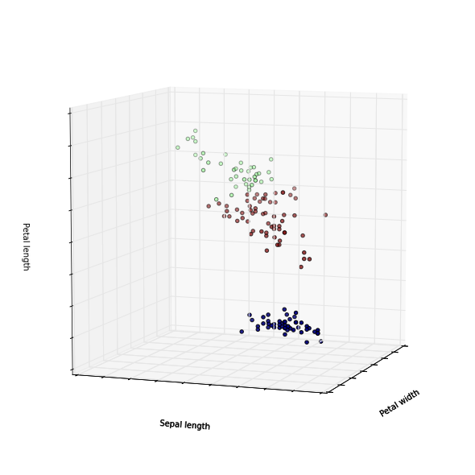

```
134 out of 150 were well predicted by the KMeans algorithm
```

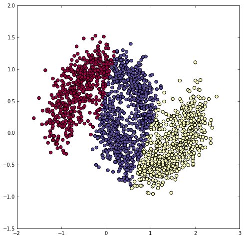

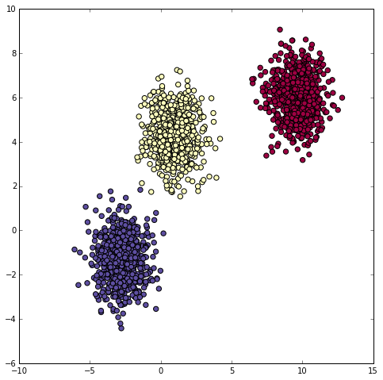

```python
# the sourcecode in this cell is inspired from
# https://gist.github.com/bbarrilleaux/9841297

%matplotlib inline

from sklearn import datasets, cluster
import numpy as np
import matplotlib.pyplot as plt
from mpl_toolkits.mplot3d import Axes3D


# load data
iris = datasets.load_iris()
X_iris = iris.data
y_iris = iris.target

# do the clustering
centers = kmeans(X_iris, k=3)
labels = [find_closest_centroid(p, centers) for p in X_iris]


#check how many labels were right
right_labels = is_label_right(labels, y_iris)
print(str(right_labels) + " out of " + str(y_iris.size) + " were well predicted by our kmeans algorithm")


#plot the clusters in color
fig = plt.figure(1, figsize=(8, 8))
plt.clf()
ax = Axes3D(fig, rect=[0, 0, 1, 1], elev=8, azim=200)
plt.cla()
ax.scatter(X_iris[:, 3], X_iris[:, 0], X_iris[:, 2], c=labels)

ax.w_xaxis.set_ticklabels([])
ax.w_yaxis.set_ticklabels([])
ax.w_zaxis.set_ticklabels([])
ax.set_xlabel('Petal width')
ax.set_ylabel('Sepal length')
ax.set_zlabel('Petal length')

plt.show()


# Here we use sci-kit learn implementation of K-means
np.random.seed(0)
centers2 =cluster.KMeans(n_clusters=3)
centers2.fit(X_iris)
labels2 = centers2.labels_
right_labels_algo = is_label_right(labels2, y_iris)
print(str(right_labels_algo) + " out of " + str(y_iris.size) + " were well predicted by the KMeans algorithm")


#moon
np.random.seed(0)
X, y = datasets.make_moons(2000, noise=0.2)

centers = kmeans(X, k=3)
labels = [find_closest_centroid(p, centers) for p in X]

fig = plt.figure(1, figsize=(8, 8))
plt.clf()
plt.scatter(X[:,0], X[:,1], s=40, c=labels, cmap=plt.cm.Spectral)
plt.show()

#blob
np.random.seed(0)
X, y = datasets.make_blobs(n_samples=2000, centers=3, n_features=20, random_state=0)

centers = kmeans(X, k=3)
labels = [find_closest_centroid(p, centers) for p in X]

fig = plt.figure(1, figsize=(8, 8))
plt.clf()
plt.scatter(X[:,0], X[:,1], s=40, c=labels, cmap=plt.cm.Spectral)
plt.show()
```

On the plot, it seems the algorithm do what we want him to do. Clusters are well cut out, especially on the blop chart. However it is not that good. Indeed, the result is not reliable, when we perform another test on the iris data, the results change and we don't have a good result. The results are sometimes also different with the Kmeans existing on python, and the results of the existing method is also different from time to time, showing us that this method is not always reliable for the iris database.  
Nevertheless it is not because points are close to eachother on the graph that they have the same label. To know more about that we computed the sum of labels that were correct (with is_right_label function). The result is often good (134 out of 150, 89%) but sometimes it is not good because the kmeans algorithm doesn't do a good cluster.

That's enough about K-means for now. In the next section, we will apply MMLIB's K-means on Spark to deal with a large data in the real usecase.

# 2. Usecase: Network Intrusion

Some attacks attempt to flood a computer with network traffic. In some other cases, attacks attempt to exploit flaws in networking software in order to gain unauthorized access to a computer. Detecting an exploit in an incredibly large haystack of network requests is not easy.

Some exploit behaviors follow known patterns such as scanning every port in a short of time, sending a burst of request to a port... However, the biggest threat may be the one that has never been detected and classified yet. Part of detecting potential network intrusions is detecting anomalies. These are connections that aren't known to be attacks, but, do not resemble connections that have been observed in the past.

In this notebook, K-means is used to detect anomalous network connections based on statistics about each of them.

## 2.1. Data

The data comes from [KDD Cup 1999](http://kdd.ics.uci.edu/databases/kddcup99/kddcup99.html). The dataset is about 708MB and contains about 4.9M connections. For each connection, the data set contains information like the number of bytes sent, login attempts, TCP errors, and so on. Each connection is one line of CSV-formatted data, containing 38 features: back, buffer_overflow, ftp_write, guess_passwd, imap, ipsweep, land, loadmodule, multihop, neptune, nmap, normal, perl, phf, pod, portsweep, rootkit, satan, smurf, spy, teardrop, warezclient, warezmaster. For more details about each feature, please follow this [link](http://kdd.ics.uci.edu/databases/kddcup99/kddcup99.html).

Many features take on the value 0 or 1, indicating the presence or absence of a behavior such as `su_attempted` in the 15th column. Some features are counts, like `num_file_creations` in the 17th columns. Some others are the number of sent and received bytes.

## 2.2. Clustering without using categorical features

First, we need to import some packages that are used in this notebook.

```python
import os
import sys
import re
from pyspark import SparkContext
from pyspark import SparkContext
from pyspark.sql import SQLContext
from pyspark.sql.types import *
from pyspark.sql import Row
from pyspark.sql.functions import *
%matplotlib inline
import matplotlib.pyplot as plt
import pandas as pd
import numpy as np
import pyspark.sql.functions as func
import matplotlib.patches as mpatches
from pyspark.mllib.clustering import KMeans, KMeansModel

input_path = "/datasets/k-means/kddcup.data"
#input_path = "/home/romain/Download_Linux/kddcup.data.corrected"
raw_data = sc.textFile(input_path, 4)
```

### 2.2.1. Loading data

There are two types of features: numerical features and categorical features. Currently, to get familiar with the data and the problem, we only use numerical features. In our data, we also have pre-defined groups for each connection, which we can use later as our "ground truth" for verifying our results.

**Note 1**: we don't use the labels in the training phase!!!

**Note 2**: in general, since clustering is un-supervised, you don't have access to ground truth. For this reason, several metrics to judge the quality of clustering have been devised. For a short overview of such metrics, follow this [link](https://en.wikipedia.org/wiki/Cluster_analysis#Internal_evaluation). Note that computing such metrics, that is trying to assess the quality of your clustering results, is as computationally intensive as computing the clustering itself!

[figure not shown]

#### Question 2

Write function `parseLine` to construct a tuple of `(label, vector)` for each connection, extract the data that contains only the data points (without label), then print the number of connections.

Where,

- `label` is the pre-defined label of each connection
- `vector` is a numpy array that contains values of all features, but the label and the categorial features at index `1,2,3` of each connection. Each `vector` is a data point.

```python
def parseLine(line):
    cols = line.split(',')
    # label is the last column
    label = cols[-1]

    # vector is every column, except the label
    vector = cols[:-1]

    # delete values of columns that have index 1->3 (categorical features)
    del(vector[1:4])

    # convert each value from string to float
    vector = np.array(vector,dtype  = 'float')

    return (label, vector)

labelsAndData = raw_data.map(parseLine)

# we only need the data, not the label
data = labelsAndData.map(lambda x : x[1]).cache()

data_sample = data.sample(withReplacement=False,fraction=0.001)

# number of connections
n = data.count()
print("The number of connection is: " + str(n))
```

```
The number of connection is: 4898431
```

[figure not shown]